# Sieanna Ruiz: Project 2

### Project 2 Online Retail

Research Question: Can we predict the total value of a single order using only attributes of that transaction (like quantity, items, time, and product)?

The dataset I will be using consits of transactional data of transactions from 01/12/2010 through 09/12/2011 for a UK-based and registered non-store online retail. I want to explore this data with predictive modeling train a linear regression model to see what prediction values I get.

# Lets Begin

```python
# Import Libraries
import pandas as pd
import numpy as np
import seaborn as sns
import matplotlib.pyplot as plt

from sklearn.model_selection import train_test_split, cross_val_score
from sklearn.preprocessing import StandardScaler
from sklearn.linear_model import LinearRegression
from sklearn.metrics import mean_squared_error, mean_absolute_error, r2_score
```

```python
# Set up plotting style
plt.style.use('default')
plt.rcParams['figure.figsize'] = (10, 6)
plt.rcParams['font.size'] = 12
```

```python
# Connect to Google Drive
from google.colab import drive
drive.mount('/content/drive')
```

# Loading and preparing our data

```python
# Load the Online retail dataset
data = pd.read_excel('/content/drive/My Drive/Colab Notebooks/Online Retail.xlsx')
print(f"Dataset shape: {data.shape}")
data.head()
```

```
Dataset shape: (541909, 8)
```

|  | InvoiceNo | StockCode | Description | Quantity | InvoiceDate | UnitPrice | CustomerID | Country |
| --- | --- | --- | --- | --- | --- | --- | --- | --- |
| 0 | 536365 | 85123A | WHITE HANGING HEART T-LIGHT HOLDER | 6 | 2010-12-01 08:26:00 | 2.55 | 17850.0 | United Kingdom |
| 1 | 536365 | 71053 | WHITE METAL LANTERN | 6 | 2010-12-01 08:26:00 | 3.39 | 17850.0 | United Kingdom |
| 2 | 536365 | 84406B | CREAM CUPID HEARTS COAT HANGER | 8 | 2010-12-01 08:26:00 | 2.75 | 17850.0 | United Kingdom |
| 3 | 536365 | 84029G | KNITTED UNION FLAG HOT WATER BOTTLE | 6 | 2010-12-01 08:26:00 | 3.39 | 17850.0 | United Kingdom |
| 4 | 536365 | 84029E | RED WOOLLY HOTTIE WHITE HEART. | 6 | 2010-12-01 08:26:00 | 3.39 | 17850.0 | United Kingdom |

# Cleaning The Data

```python
#drop missing product descriptions
df = data.dropna (subset= ["Description"])
df.shape

# remove returns or negative quantites
df = df[df["Quantity"] > 0]

# remove invalid prices
df = df[df["UnitPrice"] > 0]

# convert data
df["InvoiceDate"] = pd.to_datetime(df["InvoiceDate"])
```

# Create Order-Level Dataset

```python
# aggregate line items into orders
order_df = df.groupby("InvoiceNo").agg({
    "Quantity": "sum",
    "UnitPrice": "mean",
    "StockCode": "nunique",
    "InvoiceDate": "min"
}).rename(columns={"StockCode": "num_unique_items"})

# compute actual order value
order_df["order_value"] = (
    df.groupby("InvoiceNo")
.apply(lambda x: (x["Quantity"] * x["UnitPrice"]).sum()))
```

# Create Features

```python
order_df["month"] = order_df["InvoiceDate"].dt.month
order_df["weekday"] = order_df["InvoiceDate"].dt.weekday
```

# Select Feature Columns

```python
# Create inputs for multivariate regression
features = ["Quantity", "UnitPrice", "num_unique_items", "month", "weekday"]
X = order_df[features]
y = order_df["order_value"]
```

# Train/Test Split

```python
X_train, X_test, y_train, y_test = train_test_split(X, y, test_size=0.2, random_state=42)
```

# Scale Data

```python
scaler = StandardScaler()
X_train_scaled = scaler.fit_transform(X_train)
X_test_scaled = scaler.transform(X_test)
```

# Train Multivariate Linear Regression

```python
model = LinearRegression()
model.fit(X_train_scaled, y_train)
```

```
LinearRegression()
```

# Evaluate model

```python
preds = model.predict(X_test_scaled)
```

# Calculate Metrics

```python
mse = mean_squared_error(y_test, preds)
rmse = np.sqrt(mse)
mae = mean_absolute_error(y_test, preds)
r2 = r2_score(y_test, preds)

print("RMSE:", rmse)
print("MAE:", mae)
print("R^2:", r2)
```

```
RMSE: 443.6000754860361
MAE: 200.0183468747745
R^2: 0.7327375390561938
```

# Inspect Coefficients

```python
coef_df = pd.DataFrame({"feature": features,"coefficient": model.coef_})
coef_df
```

|  | feature | coefficient |
| --- | --- | --- |
| 0 | Quantity | 1697.482009 |
| 1 | UnitPrice | 154.112495 |
| 2 | num_unique_items | 228.393112 |
| 3 | month | 15.832760 |
| 4 | weekday | -14.148287 |

# Cross-Validation

```python
cv_rmse = -cross_val_score(model, X_train_scaled, y_train,cv=5, scoring="neg_root_mean_squared_error")

print("CV RMSE Mean:", cv_rmse.mean())
print("CV RMSE Std:", cv_rmse.std())
```

```
CV RMSE Mean: 919.7301754754769
CV RMSE Std: 370.2747681807475
```

# Basic Dataset Overview

```python
# Get basic info of the data
order_df.info()
order_df.describe()
order_df.head()
```

```
<class 'pandas.core.frame.DataFrame'>
Index: 19960 entries, 536365 to A563185
Data columns (total 7 columns):
 #   Column            Non-Null Count  Dtype
---  ------            --------------  -----
 0   Quantity          19960 non-null  int64
 1   UnitPrice         19960 non-null  float64
 2   num_unique_items  19960 non-null  int64
 3   InvoiceDate       19960 non-null  datetime64[ns]
 4   order_value       19960 non-null  float64
 5   month             19960 non-null  int32
 6   weekday           19960 non-null  int32
dtypes: datetime64[ns](1), float64(2), int32(2), int64(2)
memory usage: 1.6+ MB
```

| InvoiceNo | Quantity | UnitPrice | num_unique_items | InvoiceDate | order_value | month | weekday |
| --- | --- | --- | --- | --- | --- | --- | --- |
| 536365 | 40 | 3.910000 | 7 | 2010-12-01 08:26:00 | 139.12 | 12 | 2 |
| 536366 | 12 | 1.850000 | 2 | 2010-12-01 08:28:00 | 22.20 | 12 | 2 |
| 536367 | 83 | 4.853333 | 12 | 2010-12-01 08:34:00 | 278.73 | 12 | 2 |
| 536368 | 15 | 4.775000 | 4 | 2010-12-01 08:34:00 | 70.05 | 12 | 2 |
| 536369 | 3 | 5.950000 | 1 | 2010-12-01 08:35:00 | 17.85 | 12 | 2 |

# Distribution of Order Value

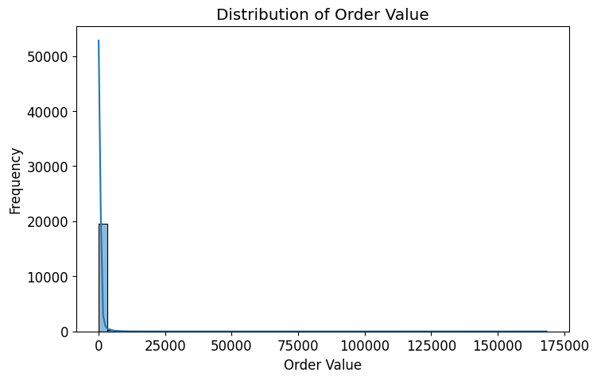

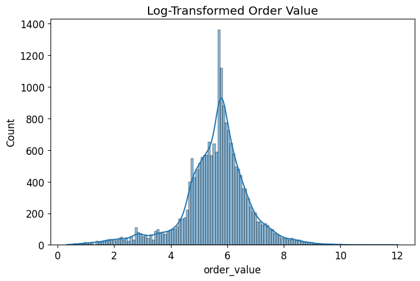

```python
plt.figure(figsize=(8,5))
sns.histplot(order_df["order_value"], bins=50, kde=True)
plt.title("Distribution of Order Value")
plt.xlabel("Order Value")
plt.ylabel("Frequency")
plt.show()

# Log transformed plot (more readable)
plt.figure(figsize=(8,5))
sns.histplot(np.log1p(order_df["order_value"]), kde=True)
plt.title("Log-Transformed Order Value")
plt.show()
```

### What first plot shows

- The distribution is extremely right-skewed.
- Most orders are low value, while a small number of invoices have very large totals.
- This pattern is typical in real-world retail data

### Second plot why log-transform?

- Reduces the impact of extreme outliers
- Makes the distribution more symmetric
- Helps linear regression perform better
- Creates a more stable relationship between predictors and the target variable

### Result

After the log transform, the distribution becomes much smoother and closer to a normal shape. This makes it more appropriate to train a regression model that predicts order value.

### Relationship Between Key Predictiors and Order Value

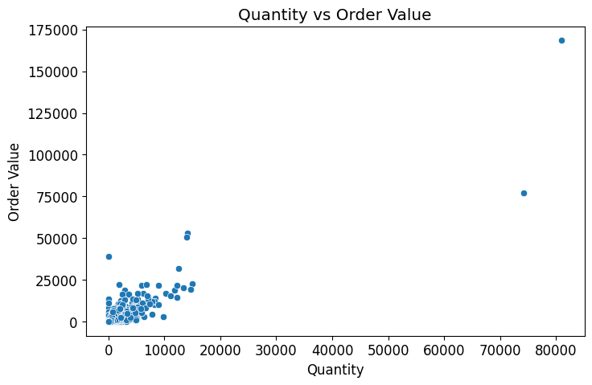

```python
# Quanity vs Order Value
plt.figure(figsize=(8,5))
sns.scatterplot(x="Quantity", y="order_value", data=order_df)
plt.title("Quantity vs Order Value")
plt.xlabel("Quantity")
plt.ylabel("Order Value")
```